# FEMALE EMPLOYMENT AND SOCIO-ECONOMIC FACTORS

## GROUP 2: Business

## Group Members: Anusha Reddy,Pranjali Singh

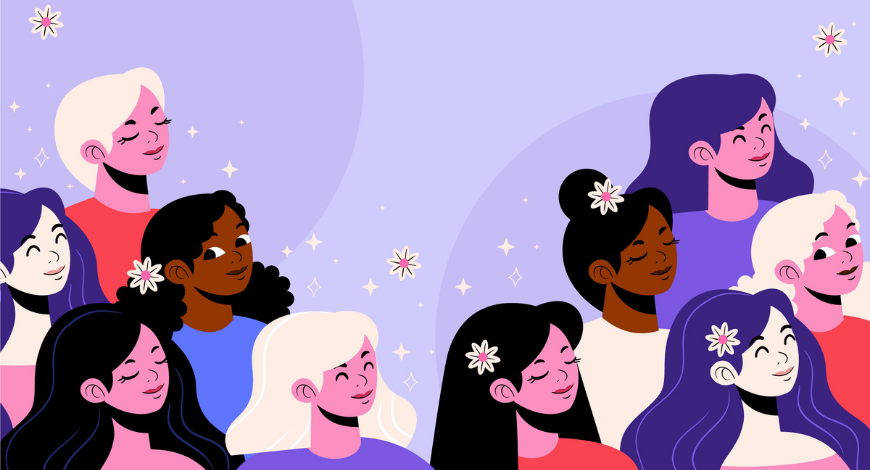

1. **Objective of the Proposed Research: Describe in your own words the objective of the research in 3 paragraphs or more. Who is your stakeholder and how this project will help him/her with their decisions. Your stakeholder can be one person (e.g. the Police Commissioner, Stockton Mayor) or an entity (e.g. Century Fox Entertainment)**

Socio-Economic status can be interlinked to various parameters like financial independence,Health, education, and social status of women in the World. There have been several researches and studies over this that show how parameters like these are affecting the rate of employment for women.

This data has been collected from Survey being done on Bangladesh as a country on whole. Also,it has been customed from the various data records from World Bank and other global organisations. During the analysis, detailed analysis of each and every factor is forseen. The main motive behind the report is to outline as well as assess in detail ,how the employement sector has experienced a drastic change over a span of time. This shall help government in analysing its past policies and norms for upliftment of the women in the society.

When it comes to the Stakeholders associated to this Report; primarily it is the Women of the Society and also it is crucial for the government of the country. This report consists of analysing changes in conditions of women, be it in the past few years or predicting future self. The various trends and patterns can also be seen amongst different sectors of the economy. This shall help the Government to analyse its policies and aftermaths over the years and also predict and plan for future ahead.

WHY FEMALE EMPLOYEMENT?

1. MORE WORKING WOMEN WOULD NARROW THE SKILLS GAP

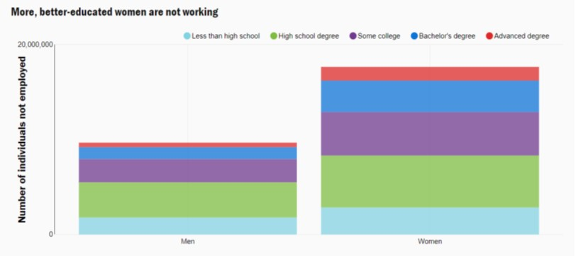

2. MORE WORKING WOMEN WOULD BOOST GROWTH

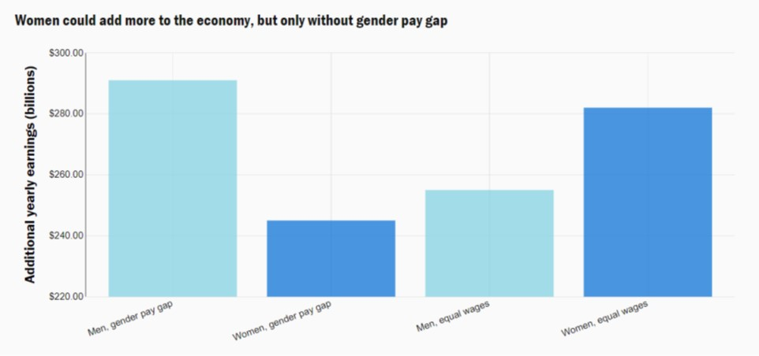

3. MORE WORKING WOMEN WOULD CUT CHILD POVERTY

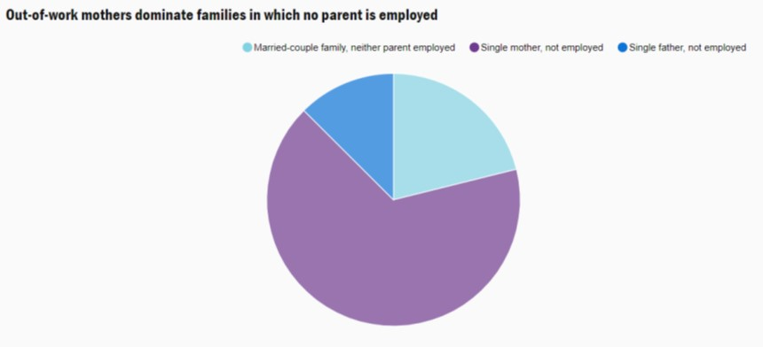

1. **Data** Exploration: Describe your data with code (and text) depicting at least 4 different aspects of your it.

```r
#Reading dataset
mydataset <- read.csv("/content/Female Employement vs .csv")
```

```r
#1
summary(mydataset)
```

```
      Year       PerFemEmploy   FertilityRate      Ratio_MaletoFemale
 Min.   :1995   Min.   :24.30   Length:25          Min.   :28.33
 1st Qu.:2001   1st Qu.:25.78   Class :character   1st Qu.:31.02
 Median :2007   Median :26.56   Mode  :character   Median :33.50
 Mean   :2007   Mean   :27.68                      Mean   :34.95
 3rd Qu.:2013   3rd Qu.:28.99                      3rd Qu.:38.49
 Max.   :2019   Max.   :33.82                      Max.   :44.50
 PerFemEmployers   Agriculture       Industry        Services
 Min.   :0.0900   Min.   :59.03   Min.   : 7.46   Min.   : 7.56
 1st Qu.:0.1000   1st Qu.:64.73   1st Qu.: 9.01   1st Qu.:13.55
 Median :0.1200   Median :67.52   Median :12.62   Median :19.87
 Mean   :0.1964   Mean   :70.27   Mean   :12.02   Mean   :17.71
 3rd Qu.:0.1600   3rd Qu.:77.44   3rd Qu.:14.42   3rd Qu.:20.86
 Max.   :0.6600   Max.   :84.79   Max.   :16.78   Max.   :24.27
 Wage.Salaried   ContrFamWorkers   OwnAccount      Vulnerable
 Min.   :16.56   Min.   :27.99   Min.   :15.07   Min.   :66.73
 1st Qu.:19.11   1st Qu.:52.41   1st Qu.:15.52   1st Qu.:77.11
 Median :20.81   Median :61.29   Median :17.48   Median :79.09
 Mean   :21.97   Mean   :55.87   Mean   :21.97   Mean   :77.84
 3rd Qu.:22.78   3rd Qu.:64.07   3rd Qu.:26.47   3rd Qu.:80.79
 Max.   :32.61   Max.   :66.80   Max.   :38.74   Max.   :83.27
```

```r
#2
dim(mydataset)
```

1. 25

2. 12

There are 25 rows and 12 columns in this data. Each of the 25 rows depict the yearwise data of women employement and helps to do anlaysis over 12 parameters and variables. Some of them are dependent and some are independent.

```r
#3
x <- c(mydataset$Agriculture+ mydataset$Industry+mydataset$Services)
print(x)
```

```
 [1] 100.01 100.01 100.00 100.00 100.00 100.00 100.00 100.00 100.00 100.00
[11] 100.00 100.00 100.01 100.00 100.00 100.00 100.01 100.00 100.00 100.00
[21] 100.00 100.00 100.00 100.00 100.00
```

```r
#4 Creating row indicator and # Subset even rows
row_odd <- seq_len(nrow(mydataset)) %% 2
data_row_even <- mydataset[row_odd == 0, ]
data_row_even
```

A data.frame: 12 × 12

|  | Year <int> | PerFemEmploy <dbl> | FertilityRate <chr> | Ratio_MaletoFemale <dbl> | PerFemEmployers <dbl> | Agriculture <dbl> | Industry <dbl> | Services <dbl> | Wage.Salaried <dbl> | ContrFamWorkers <dbl> | OwnAccount <dbl> | Vulnerable <dbl> |
| --- | --- | --- | --- | --- | --- | --- | --- | --- | --- | --- | --- | --- |
| 2 | 1996 | 24.57 | 3.59 | 28.72 | 0.10 | 82.28 | 7.46 | 10.27 | 18.38 | 66.39 | 15.14 | 81.52 |
| 4 | 1998 | 25.11 | 3.37 | 29.67 | 0.10 | 80.28 | 7.77 | 11.95 | 19.11 | 65.53 | 15.26 | 80.79 |
| 6 | 2000 | 25.63 | 3.17 | 30.66 | 0.10 | 78.78 | 8.65 | 12.57 | 19.90 | 64.53 | 15.47 | 80.00 |
| 8 | 2002 | 25.89 | 2.97 | 31.40 | 0.11 | 75.96 | 9.51 | 14.53 | 20.81 | 63.46 | 15.63 | 79.09 |
| 10 | 2004 | 25.89 | 2.78 | 32.13 | 0.11 | 72.48 | 10.83 | 16.69 | 21.73 | 62.42 | 15.74 | 78.16 |
| 12 | 2006 | 26.11 | 2.60 | 32.74 | 0.12 | 68.19 | 12.50 | 19.31 | 22.78 | 61.17 | 15.94 | 77.11 |
| 14 | 2008 | 27.00 | 2.45 | 34.29 | 0.14 | 66.86 | 12.75 | 20.39 | 19.45 | 61.29 | 19.11 | 80.40 |
| 16 | 2010 | 28.56 | 2.32 | 35.94 | 0.17 | 65.53 | 13.05 | 21.42 | 16.56 | 60.49 | 22.77 | 83.27 |
| 18 | 2012 | 28.87 | 2.23 | 37.62 | 0.12 | 65.02 | 13.94 | 21.04 | 19.47 | 55.16 | 25.25 | 80.41 |
| 20 | 2014 | 29.49 | 2.15 | 39.38 | 0.15 | 64.36 | 14.90 | 20.74 | 23.39 | 47.84 | 28.63 | 76.47 |
| 22 | 2016 | 30.47 | 2.09 | 41.21 | 0.37 | 63.38 | 15.94 | 20.68 | 28.09 | 39.06 | 32.49 | 71.54 |
| 24 | 2018 | 33.65 | - | 44.27 | 0.65 | 59.43 | 16.74 | 23.83 | 31.89 | 28.89 | 38.58 | 67.47 |

```r
#5
mean(mydataset$Wage.Salaried)
```

21.9652

On an average about 22% women have been working under paid employement since the year 1995 to 2019.

```r
#6
subset1 =mydataset[c(1:20),c(1,3)]
subset1
```

A data.frame: 20 × 2

|  | Year <int> | FertilityRate <chr> |
| --- | --- | --- |
| 1 | 1995 | 3.71 |
| 2 | 1996 | 3.59 |
| 3 | 1997 | 3.48 |
| 4 | 1998 | 3.37 |
| 5 | 1999 | 3.27 |
| 6 | 2000 | 3.17 |
| 7 | 2001 | 3.07 |
| 8 | 2002 | 2.97 |
| 9 | 2003 | 2.88 |
| 10 | 2004 | 2.78 |
| 11 | 2005 | 2.69 |
| 12 | 2006 | 2.60 |
| 13 | 2007 | 2.52 |
| 14 | 2008 | 2.45 |
| 15 | 2009 | 2.38 |
| 16 | 2010 | 2.32 |
| 17 | 2011 | 2.27 |
| 18 | 2012 | 2.23 |
| 19 | 2013 | 2.19 |
| 20 | 2014 | 2.15 |

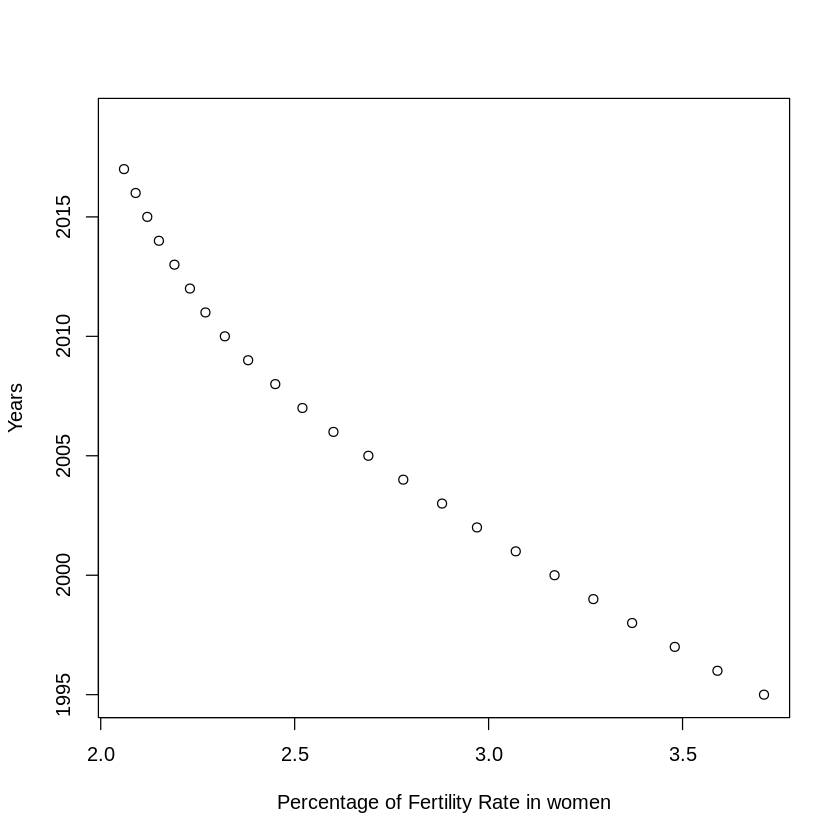

```r
plot(mydataset$Year ~ mydataset$FertilityRate, xlab = "Percentage of Fertility Rate in women", ylab = "Years")
```

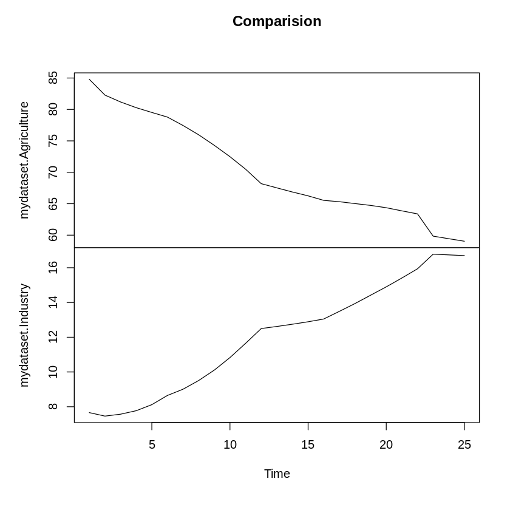

```r
#7
Comparision <- data.frame(mydataset$Agriculture,mydataset$Industry)
plot.ts(Comparision)
```

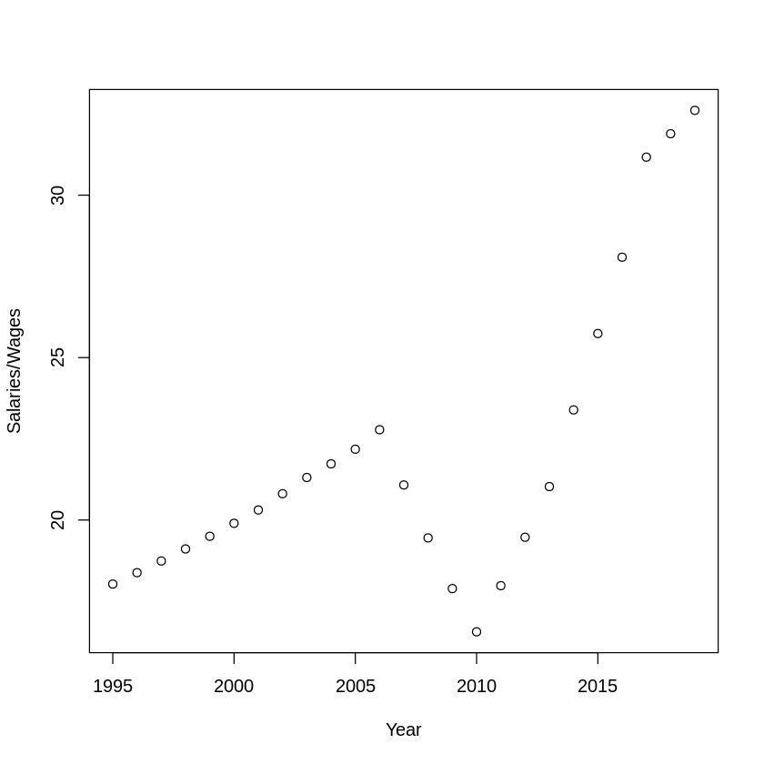

```r
#8
plot(mydataset$Wage.Salaried ~mydataset$Year, xlab = 'Year',ylab = 'Salaries/Wages')
```

Number of women working under paid employement saw a gradual rise till the year 2005, But then came a steep decline in next 5 years. Somehow the situations improved again with steep rise in their paid employement in next 5 years and since then, the growth in paid employement has been linear. This can be seen as an example of how women are supressed just when they are about to break barriers for themselves. Early marriages, household chores, not getting proper education and poor health all together are responsible for the sharp and abrupt decline.And it is the will and self motivation of women that keeps them going great towards a sharp and speedy growth rate in employment sector.

**3. Data Cleaning: Clean the data, removing rows and columns that have no useful information or no information at all.**

```r
is.null(mydataset)
```

FALSE

**4. Adaptation: Create at least two additional columns that are necessary for your study. They can be calculated columns or aggregated columns.**

```r
vec1 <- c(mydataset$Agriculture+ mydataset$Industry+mydataset$Services)
data1 <- mydataset
data1 <-cbind(mydataset,Or_Sector = vec1)

vec2 <-c(data1$ContrFamWorkers+data1$OwnAccount+data1$Vulnerable)
data2 <- data1
data2 <- cbind(data1,Unor_Sector= vec2)
head(data2)
```

A data.frame: 6 × 14

|  | Year <int> | PerFemEmploy <dbl> | FertilityRate <chr> | Ratio_MaletoFemale <dbl> | PerFemEmployers <dbl> | Agriculture <dbl> | Industry <dbl> | Services <dbl> | Wage.Salaried <dbl> | ContrFamWorkers <dbl> | OwnAccount <dbl> | Vulnerable <dbl> | Or_Sector <dbl> | Unor_Sector <dbl> |
| --- | --- | --- | --- | --- | --- | --- | --- | --- | --- | --- | --- | --- | --- | --- |
| 1 | 1995 | 24.30 | 3.71 | 28.33 | 0.1 | 84.79 | 7.66 | 7.56 | 18.03 | 66.80 | 15.07 | 81.87 | 100.01 | 163.74 |
| 2 | 1996 | 24.57 | 3.59 | 28.72 | 0.1 | 82.28 | 7.46 | 10.27 | 18.38 | 66.39 | 15.14 | 81.52 | 100.01 | 163.05 |
| 3 | 1997 | 24.82 | 3.48 | 29.18 | 0.1 | 81.19 | 7.57 | 11.24 | 18.74 | 65.95 | 15.21 | 81.16 | 100.00 | 162.32 |
| 4 | 1998 | 25.11 | 3.37 | 29.67 | 0.1 | 80.28 | 7.77 | 11.95 | 19.11 | 65.53 | 15.26 | 80.79 | 100.00 | 161.58 |
| 5 | 1999 | 25.38 | 3.27 | 30.17 | 0.1 | 79.52 | 8.12 | 12.36 | 19.50 | 65.01 | 15.39 | 80.40 | 100.00 | 160.80 |
| 6 | 2000 | 25.63 | 3.17 | 30.66 | 0.1 | 78.78 | 8.65 | 12.57 | 19.90 | 64.53 | 15.47 | 80.00 | 100.00 | 160.00 |

### LINEAR REGRESSION

```
Call:
lm(formula = mydataset$PerFemEmploy ~ mydataset$PerFemEmployers)

Residuals:
    Min      1Q  Median      3Q     Max
-2.0261 -0.6366 -0.4054  0.3496  2.8045

Coefficients:
                          Estimate Std. Error t value Pr(>|t|)
(Intercept)                 24.921      0.403   61.84  < 2e-16 ***
mydataset$PerFemEmployers   14.053      1.529    9.19 3.67e-09 ***
---
Signif. codes:  0 ‘***’ 0.001 ‘**’ 0.01 ‘*’ 0.05 ‘.’ 0.1 ‘ ’ 1

Residual standard error: 1.343 on 23 degrees of freedom
Multiple R-squared:  0.786,	Adjusted R-squared:  0.7767
F-statistic: 84.46 on 1 and 23 DF,  p-value: 3.671e-09
```

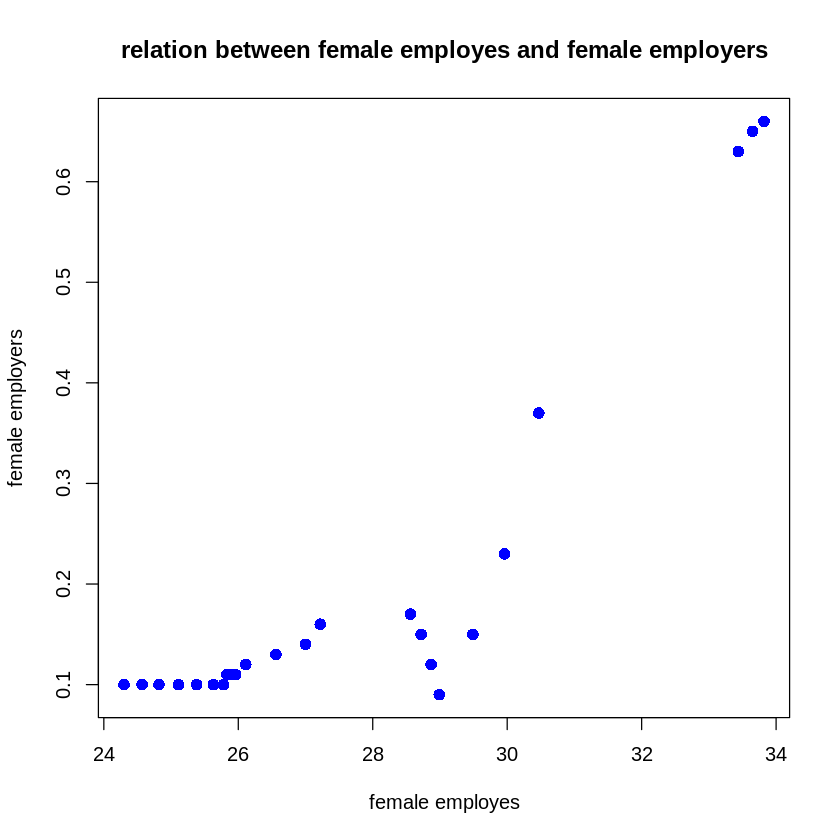

```r
#Model1
plot(mydataset$PerFemEmploy, mydataset$PerFemEmployers,
  pch = 16,
  cex = 1.3,
  col = "blue",
  main = "relation between female employes and female employers",
  xlab = "female employes",
  ylab = "female employers")

model_one <- lm(mydataset$PerFemEmploy ~ mydataset$PerFemEmployers)
model_one=summary(model_one)
abline(model_one)

print(model_one)
```

This LR Model shows that the coefficients and intercept line as given below y= 24.921 + 14.053x1 And p-value: 3.671e-09

```
Call:
lm(formula = mydataset$OwnAccount ~ mydataset$ContrFamWorkers)

Residuals:
    Min      1Q  Median      3Q     Max
-2.5849 -1.1197 -0.4306  0.6631  3.8030

Coefficients:
                          Estimate Std. Error t value Pr(>|t|)
(Intercept)               58.29050    1.68945    34.5   <2e-16 ***
mydataset$ContrFamWorkers -0.65008    0.02955   -22.0   <2e-16 ***
---
Signif. codes:  0 ‘***’ 0.001 ‘**’ 0.01 ‘*’ 0.05 ‘.’ 0.1 ‘ ’ 1

Residual standard error: 1.792 on 23 degrees of freedom
Multiple R-squared:  0.9546,	Adjusted R-squared:  0.9527
F-statistic:   484 on 1 and 23 DF,  p-value: < 2.2e-16
```

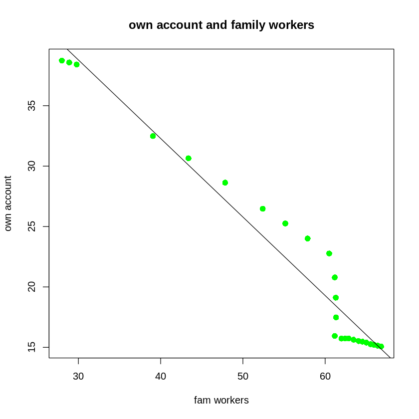

```r
#Model2
plot(mydataset$ContrFamWorkers,mydataset$OwnAccount,
  pch = 16,
  cex = 1.3,
  col = "green",
  main = "own account and family workers",
  xlab = "fam workers",
  ylab = "own account")

model_two <- lm(mydataset$OwnAccount ~ mydataset$ContrFamWorkers)
model_two=summary(model_two)
abline(model_two)

print(model_two)
```

This LR Model shows that the coefficients and intercept line as given below y= 58.29050 -0.65008x1 And p-value < 2.2e-16

```r
#Model3
SM1 = lm(mydataset$Agriculture~mydataset$Wage.Salaried, data = mydataset)
SM1 = summary(SM1)
SM1
```

```
Call:
lm(formula = mydataset$Agriculture ~ mydataset$Wage.Salaried,
    data = mydataset)

Residuals:
     Min       1Q   Median       3Q      Max
-10.6551  -4.3538   0.0143   5.3570  10.2129

Coefficients:
                        Estimate Std. Error t value Pr(>|t|)
(Intercept)              94.2999     6.2456  15.099 1.99e-13 ***
mydataset$Wage.Salaried  -1.0939     0.2788  -3.924 0.000679 ***
---
Signif. codes:  0 ‘***’ 0.001 ‘**’ 0.01 ‘*’ 0.05 ‘.’ 0.1 ‘ ’ 1

Residual standard error: 6.163 on 23 degrees of freedom
Multiple R-squared:  0.401,	Adjusted R-squared:  0.375
F-statistic:  15.4 on 1 and 23 DF,  p-value: 0.0006788
```

This LR Model shows that the coefficients and intercept line as given below y= 94.2999 -1.0939x1 And p-value:0.0006788

```
Call:
lm(formula = mydataset$Agriculture ~ mydataset$Agriculture)

Residuals:
    Min      1Q  Median      3Q     Max
-11.242  -5.542  -2.752   7.168  14.518

Coefficients:
            Estimate Std. Error t value Pr(>|t|)
(Intercept)   70.272      1.559   45.08   <2e-16 ***
---
Signif. codes:  0 ‘***’ 0.001 ‘**’ 0.01 ‘*’ 0.05 ‘.’ 0.1 ‘ ’ 1

Residual standard error: 7.795 on 24 degrees of freedom
```

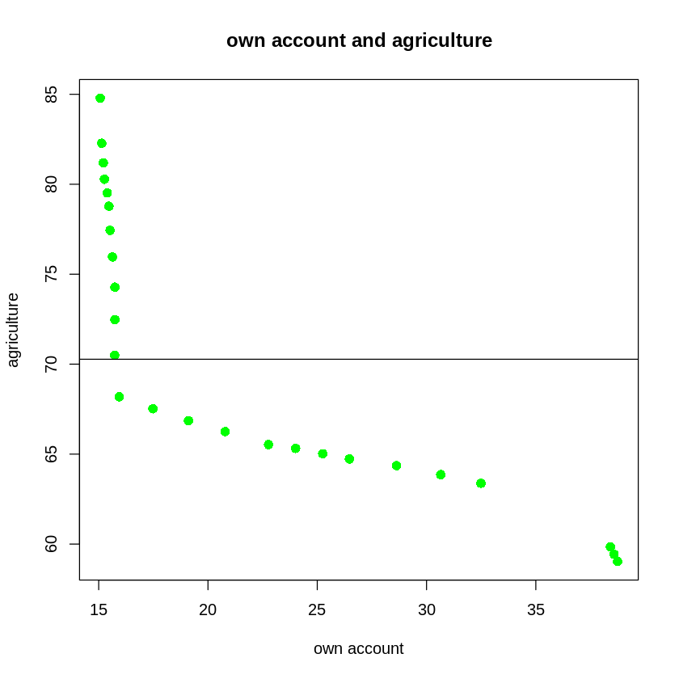

```r
#Model4
plot(
  mydataset$OwnAccount,
  mydataset$Agriculture,
  pch = 16,
  cex = 1.3,
  col = "green",
  main = "own account and agriculture",
  xlab = "own account",
  ylab = "agriculture")

model_four <- lm(mydataset$Agriculture ~ mydataset$Agriculture)

abline(model_four)
model_four=summary(model_four)
print(model_four)
```

This LR Model shows that the coefficient is 70.272.

### MULTIPLE LINEAR REGRESSION

```
Call:
lm(formula = mydataset$Agriculture ~ mydataset$Industry + mydataset$Services,
    data = mydataset)

Residuals:
       Min         1Q     Median         3Q        Max
-0.0029392 -0.0018549 -0.0010441 -0.0004471  0.0094815

Coefficients:
                     Estimate Std. Error t value Pr(>|t|)
(Intercept)         1.000e+02  3.002e-03   33309   <2e-16 ***
mydataset$Industry -9.996e-01  8.055e-04   -1241   <2e-16 ***
mydataset$Services -1.000e+00  5.423e-04   -1845   <2e-16 ***
---
Signif. codes:  0 ‘***’ 0.001 ‘**’ 0.01 ‘*’ 0.05 ‘.’ 0.1 ‘ ’ 1

Residual standard error: 0.003729 on 22 degrees of freedom
Multiple R-squared:      1,	Adjusted R-squared:      1
F-statistic: 5.242e+07 on 2 and 22 DF,  p-value: < 2.2e-16
```

```
Call:
lm(formula = mydataset$Agriculture ~ mydataset$Industry + mydataset$Services,
    data = mydataset)

Residuals:
       Min         1Q     Median         3Q        Max
-0.0029392 -0.0018549 -0.0010441 -0.0004471  0.0094815

Coefficients:
                     Estimate Std. Error t value Pr(>|t|)
(Intercept)         1.000e+02  3.002e-03   33309   <2e-16 ***
mydataset$Industry -9.996e-01  8.055e-04   -1241   <2e-16 ***
mydataset$Services -1.000e+00  5.423e-04   -1845   <2e-16 ***
---
Signif. codes:  0 ‘***’ 0.001 ‘**’ 0.01 ‘*’ 0.05 ‘.’ 0.1 ‘ ’ 1

Residual standard error: 0.003729 on 22 degrees of freedom
Multiple R-squared:      1,	Adjusted R-squared:      1
F-statistic: 5.242e+07 on 2 and 22 DF,  p-value: < 2.2e-16
```

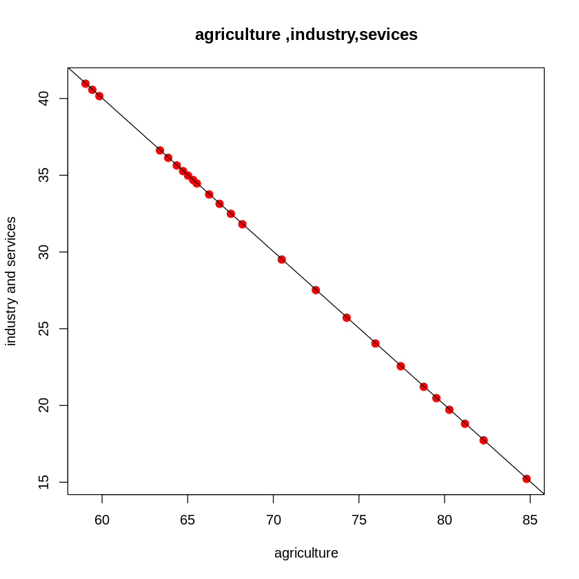

```r
plot(mydataset$Agriculture, mydataset$Industry+mydataset$Services,
  pch = 20,
  cex = 1.8,
  col = "red",
  main = "agriculture ,industry,sevices",
  xlab = "agriculture",
  ylab = "industry and services")
MR1 = lm(mydataset$Agriculture ~ mydataset$Industry + mydataset$Services, data = mydataset)
MR1 = summary(MR1)
MR1
abline(MR1)

print(MR1)
```

```
Call:
lm(formula = mydataset$Year ~ mydataset$Wage.Salaried + mydataset$Vulnerable +
    mydataset$Vulnerable, data = mydataset)

Residuals:
   Min     1Q Median     3Q    Max
-8.168 -3.734 -1.445  5.129  8.111

Coefficients:
                        Estimate Std. Error t value Pr(>|t|)
(Intercept)              3455.37    1416.37   2.440   0.0232 *
mydataset$Wage.Salaried   -14.03      14.59  -0.962   0.3467
mydataset$Vulnerable      -14.65      14.08  -1.040   0.3095
---
Signif. codes:  0 ‘***’ 0.001 ‘**’ 0.01 ‘*’ 0.05 ‘.’ 0.1 ‘ ’ 1

Residual standard error: 5.341 on 22 degrees of freedom
Multiple R-squared:  0.5172,	Adjusted R-squared:  0.4733
F-statistic: 11.78 on 2 and 22 DF,  p-value: 0.0003324
```

```
Call:
lm(formula = mydataset$Year ~ mydataset$Wage.Salaried + mydataset$Vulnerable +
    mydataset$Vulnerable, data = mydataset)

Residuals:
   Min     1Q Median     3Q    Max
-8.168 -3.734 -1.445  5.129  8.111

Coefficients:
                        Estimate Std. Error t value Pr(>|t|)
(Intercept)              3455.37    1416.37   2.440   0.0232 *
mydataset$Wage.Salaried   -14.03      14.59  -0.962   0.3467
mydataset$Vulnerable      -14.65      14.08  -1.040   0.3095
---
Signif. codes:  0 ‘***’ 0.001 ‘**’ 0.01 ‘*’ 0.05 ‘.’ 0.1 ‘ ’ 1

Residual standard error: 5.341 on 22 degrees of freedom
Multiple R-squared:  0.5172,	Adjusted R-squared:  0.4733
F-statistic: 11.78 on 2 and 22 DF,  p-value: 0.0003324
```

[figure not shown]

```r
plot(
  mydataset$Year,
  mydataset$Wage.Salaried+mydataset$Vulnerable+mydataset$Vulnerable,
  pch = 20,
  cex = 1.8,
  col = "red",
  main = "agriculture ,industry,sevices",
  xlab = "agriculture",
  ylab = "industry and services")
MR2 = lm(mydataset$Year ~ mydataset$Wage.Salaried + mydataset$Vulnerable+mydataset$Vulnerable, data = mydataset)
MR2 = summary(MR2)
MR2
abline(MR2)

print(MR2)
```

### REPORT

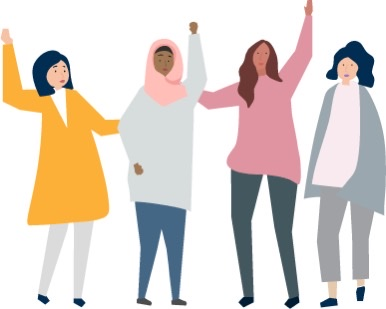

There is a consolidated analysis on how circumstances have changed over the years for Females in the Employment Sector. The report takes into consideration of Females working as employee in other firms or having their own private ventures.

To start with the yearwise analysis, a clear picture depicts extremely poor scenarios for women during 1995, but they somehow are at a progressive approach in current scenarios. Female participation and involvement has seen a rise and they are no more just focusing on household responsibilities.

Do Women prefer to be Employeed or be the employer themselves? To be employeed is what somehow gives a sense of job security to women. Henceforth, their focus lie towards being employeed in other firms rather than taking risk of business failure.

Despite of being highly educated and skilled over the years, majority women still seems to be working in agricultural sector. It is commonly relatable to those who lack literacy and skills and that is why end up working as labor force in unorganised sector.

To study pattern in service sector,we observed a growth from 7% to 24% over the years- but in between there was a slight fall observed too.As Being working for underpaid jobs as compared to men can be a demotivating factor too.So women tend to change professions often or probably shuffle between private ventures or sometimes end up joining family business for the sake.

Industrial sector is known to be the future for any country, considering technological advancements- be it in small manufacturing firms like Texttile and Handloom or Carpet making, Candle making, Bangle Manufactures or Big merchandises.

It was not surprising to find that Women prefer working for others as employees under not favorable conditions like low wages, odd hours, commuting to far away places for work; rather than setting up their own business or firm. This could possibly be affirmed with the due to challenges with household responsibilities, children. As private owned business would require more time and liability, so they end up working as employees. But a slow and gradual rise can also be seen over the years, where women have started getting into onw ventures. That signifies a mark of risk taking capacity as well as boost of self confidence.

Most important pattern to be observed is: Vulnerability! Though it has decreased from a high of 81.87% to 66.73%, but there has been significant amount of changes both constructive and destructive over the years. Probably because of the changing scenarios for the women with respect to Gender Roles. From being able to get higher education to getting employed at high end job roles and working as CEO of MNCs. A prevailing mindset still appreciates a women taking care of household well over the one who is a successful enterpreneur or probably earning a six or seven digit salary.

*Our intended Stakeholders for this project are:*

1. Government –Policies and Measures Government can have a major usage of this analysis while accessing their existing laws and promote measures for a equal gender society.
2. Universities and Schools Universities and schools can get an insight on scenarios for female education and availablity of technical skills and features required in the market.
3. Scholars and Policy Makers It is easier to review impact and plan ahead for further necessary actions.
4. Non Government Organizations and Non Profit Organizations NGOs and NPOs can locate their target fields to work upon.
5. Research and Analysts Each and every bit of data analysis can be a big contribution for researchers. As there inferences drawn out of this might help in some sort of developed or discovery.
6. General Public – awareness about Female employment. As this study revolves around lot of socio-economic factors, it would be able to make a significant impact on generating awareness about Female employment and its driving parameters.
7. MNC and Corporates- how well women are establishing a work-life balance. A secure and comforting work enviroment is still every women's desire.Henceforth this data can be helpful for MNC to inculcate a more welcoming enviroment and opportunities for women.
8. Men in Society- One of the most impactful stakeholders for this study are Men. As they can be proud of the Women in the house and value their contribution. Also motivate them for further advancements and career goals. Specially getting more women into technical fields.

'Behind every successful women, there is a men(Be it a father, Brother, Husband or a Son)'

### ORIGINALITY

No other similar published works for linear regression found with same dataset.